# R Notebook

# Principal Components Analysis

Let’s look for the modes of variability in this diamonds dataset:

```r
library(ggplot2)
head(diamonds)
#let's make a big plot avoiding the three rows that aren't data
plot(diamonds[1:100,-c(2,3,4)])

Xraw = diamonds[1:1000,-c(2,3,4)]
```

[output not shown]

OK, now we need to calculate a covariance matrix

```r
head(cor(Xraw))
```

```
           carat       depth       table       price           x          y          z
carat 1.00000000  0.09528927  0.12698220  0.85755776  0.97759478  0.9725800 0.98088588
depth 0.09528927  1.00000000 -0.34472255 -0.01258316 -0.05033068 -0.0584113 0.21134454
table 0.12698220 -0.34472255  1.00000000  0.06805856  0.13268231  0.1127549 0.03173969
price 0.85755776 -0.01258316  0.06805856  1.00000000  0.91114241  0.9172024 0.89291925
x     0.97759478 -0.05033068  0.13268231  0.91114241  1.00000000  0.9962234 0.96422550
y     0.97257997 -0.05841130  0.11275493  0.91720237  0.99622344  1.0000000 0.96198408
```

So let’s do PCA on the correlation matrix, since the units are different in our column

```r
#Now that we have our covariance/correlation matrix, we can use svd to find the eigen values and vectors:
out = svd(coMat)
names(out)
```

[output not shown]

OK, remember our SVD formulation

$A = EDE^T$

Where A is our covariance matrix, E is our eigenvectors, and D is our Eigenvalues? svd names E=U, and $E^T$ = V

We can also think our eigen matrix as our new covariance matrix, with zeros off the diagonal.

```r
print(out$d)#svd returns only, the diagonal.
```

```
[1] 4.7880252909 1.3755317522 0.6721094682 0.1531485875 0.0073524900 0.0032904137 0.0005419975
```

OK, so now we have 7 indepenent modes of variability, that explain all the variance, independently.

But can we take our data, and “project it” onto this new coordinate system. Yes we can!

```r
cov(PCs)
```

```
              [,1]          [,2]          [,3]          [,4]          [,5]          [,6]          [,7]
[1,]  4.788025e+00  1.088274e-16  7.547207e-16  1.975972e-15  1.247338e-15 -2.902639e-16 -1.212482e-15
[2,]  1.088274e-16  1.375532e+00 -5.201193e-15 -6.571450e-16  5.036329e-17 -9.188373e-17  1.872705e-16
[3,]  7.547207e-16 -5.201193e-15  6.721095e-01  9.102421e-16  5.596977e-16 -2.114764e-16 -1.862541e-16
[4,]  1.975972e-15 -6.571450e-16  9.102421e-16  1.531486e-01 -3.104636e-15  1.681546e-15  1.231895e-15
[5,]  1.247338e-15  5.036329e-17  5.596977e-16 -3.104636e-15  7.352490e-03  1.015341e-15  6.328519e-16
[6,] -2.902639e-16 -9.188373e-17 -2.114764e-16  1.681546e-15  1.015341e-15  3.290414e-03  7.793012e-16
[7,] -1.212482e-15  1.872705e-16 -1.862541e-16  1.231895e-15  6.328519e-16  7.793012e-16  5.419975e-04
```

OK, great. How can we explore these data?

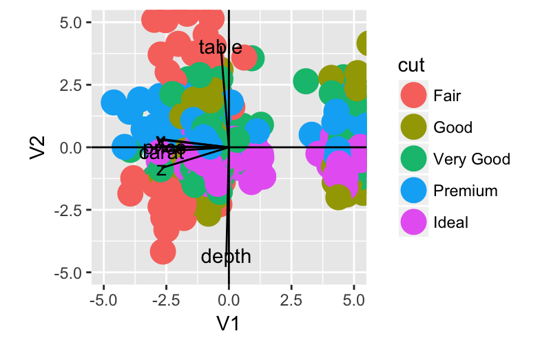

```r
df = cbind(as.data.frame(PCs),diamonds[1:nrow(X),]) #let's make a big data frame with the original data, and our PCs
df2 = cbind(as.data.frame(out$v),names(diamonds[,-c(2,3,4)])) #and a second with just the eigenvectors
names(df2)[8]="names"
arrowScale=6
ggplot(df, aes(x = V1, y= V2))+geom_point(aes(colour=cut),size=6)+geom_hline(yintercept=0)+geom_vline(xintercept=0)+coord_fixed(xlim=c(-5,5),ylim=c(-5,5))+geom_segment(data=df2,aes(x=0,y=0,xend = V1*arrowScale, yend = V2*arrowScale))+geom_text(data=df2,aes(x = V1*arrowScale, y = V2*arrowScale,label=names) )
```

# Mapping!

To map, we will use the ggmap package which integrates nicely with ggplot

```r
library(ggmap)
```

And for fun, let’s take a look at a spatial database of vehicle accidents…

```r
mydata = read.csv("vehicle-accidents.csv")
head(mydata)
```

|  | State | MV.Percent | MV.Number | NM.Percent | NM.Number | FO.Percent | FO.Number | ONF.Percent | ONF.Number | OT.Percent | OT.Number |
| --- | --- | --- | --- | --- | --- | --- | --- | --- | --- | --- | --- |
| 1 | Alabama | 38.7 | 78 | 9.6 | 326 | 40.3 | 20 | 2.5 | 68 | 8.4 | 4 |
| 2 | Alaska | 42.6 | 9 | 16.7 | 9 | 16.7 | 5 | 9.3 | 8 | 14.8 | 0 |
| 3 | Arizona | 31.7 | 145 | 19.5 | 177 | 23.9 | 12 | 1.6 | 137 | 18.5 | 21 |
| 4 | Arkansas | 36.2 | 46 | 9.3 | 183 | 36.8 | 13 | 2.6 | 64 | 12.9 | 11 |
| 5 | California | 30.8 | 722 | 27.4 | 728 | 27.7 | 85 | 3.2 | 265 | 10.1 | 21 |
| 6 | Colorado | 33.0 | 77 | 17.8 | 116 | 26.8 | 8 | 1.8 | 86 | 19.9 | 3 |

And reformat the data slightly to make it map better

```r
head(mydata)
```

|  | State | MV.Percent | MV.Number | NM.Percent | NM.Number | FO.Percent | FO.Number | ONF.Percent | ONF.Number | OT.Percent | OT.Number |
| --- | --- | --- | --- | --- | --- | --- | --- | --- | --- | --- | --- |
| 1 | Alabama | 38.7 | 78 | 9.6 | 326 | 40.3 | 20 | 2.5 | 68 | 8.4 | 4 |
| 2 | Alaska | 42.6 | 9 | 16.7 | 9 | 16.7 | 5 | 9.3 | 8 | 14.8 | 0 |
| 3 | Arizona | 31.7 | 145 | 19.5 | 177 | 23.9 | 12 | 1.6 | 137 | 18.5 | 21 |
| 4 | Arkansas | 36.2 | 46 | 9.3 | 183 | 36.8 | 13 | 2.6 | 64 | 12.9 | 11 |
| 5 | California | 30.8 | 722 | 27.4 | 728 | 27.7 | 85 | 3.2 | 265 | 10.1 | 21 |
| 6 | Colorado | 33.0 | 77 | 17.8 | 116 | 26.8 | 8 | 1.8 | 86 | 19.9 | 3 |

```r
mydata$State = as.character(mydata$State)
mydata$MV.Number = as.numeric(mydata$MV.Number)
```

And get rid of the rows that will be a problem to map…

```r
#get rid of HI, AK, and the whole US total
mydata = mydata[mydata$State != "Alaska",]
mydata = mydata[mydata$State != "Hawaii",]
mydata = mydata[mydata$State != "USA",]
```

ggmap does a lot of awesome things. One them is the geocode() function

```r
print(c(NAU$lat,NAU$lon))
```

```
[1]   35.18309 -111.65496
```

Notice that there are no coordinates in our database. Let’s use geocode to get coordinates for our map:

```r
#get latitude and longitude
for (i in 1:nrow(mydata)){
  latlon = geocode(mydata$State[i])
  mydata$lon[i] = as.numeric(latlon[1])
  mydata$lat[i] = as.numeric(latlon[2])
}
```

Awesome. We’re ready to make a map. ggmap works by ggplotting on a base map. There are a number of ways to make base map. One is by creating a bounding box:

```r
bb = make_bbox(lat = mydata$lat, lon = mydata$lon, f = .3)
map = get_map(location = bb)
```

```
bounding box given to google - spatial extent only approximate.converting bounding box to center/zoom specification. (experimental)
```

[figure not shown]

[output not shown]

[figure not shown]

```r
theme_set(theme_bw(16))
HoustonMap <- qmap("houston", zoom = 14,color = "bw", legend = "topleft")
HoustonMap + geom_point(aes(x = lon, y = lat,colour = offense, size = offense),data = violent_crimes)
```

[figure not shown]

```r
HoustonMap +stat_bin2d(aes(x = lon, y = lat, colour = offense,fill = offense),size = .5, bins = 30, alpha = 1/2,data = violent_crimes)
```

[figure not shown]